# Loading required modules

```python
import streamlit as st
from datetime import date
import yfinance as yf

import pandas as pd
import numpy as np
import matplotlib.pyplot as plt
from math import sqrt
from sklearn import preprocessing
from sklearn.metrics import mean_squared_error
from sklearn.metrics import mean_absolute_error
from tensorflow.keras.layers import *
from tensorflow.keras.models import *
from tensorflow.keras.optimizers import Adam
import tensorflow as tf
```

```
WARNING:tensorflow:From D:\Dev\Anaconda\Lib\site-packages\keras\src\losses.py:2976: The name tf.losses.sparse_softmax_cross_entropy is deprecated. Please use tf.compat.v1.losses.sparse_softmax_cross_entropy instead.
```

```python
import math
import seaborn as sns
import datetime as dt
from datetime import datetime
sns.set_style("whitegrid")
from pandas.plotting import autocorrelation_plot
import matplotlib.pyplot as plt
%matplotlib inline
plt.style.use("ggplot")
```

# 1.Download data from yahufinance as the real data

```python
START ="2015-01-01"
Trian_day="2022-01-01"
TODAY =date.today().strftime("%Y-%m-%d")
```

```python
stocks=("AAPL")  #可以更改成想要的股票代码
# 使用yfinance下载股票数据
Trian_data = yf.download(stocks, start=START, end=Trian_day)
# 显示数据
Trian_data.tail()  # 显示最后几行数据作为示例
```

```
[*********************100%%**********************]  1 of 1 completed
```

| Date | Open | High | Low | Close | Adj Close | Volume |
| --- | --- | --- | --- | --- | --- | --- |
| 2021-12-27 | 177.089996 | 180.419998 | 177.070007 | 180.330002 | 178.292908 | 74919600 |
| 2021-12-28 | 180.160004 | 181.330002 | 178.529999 | 179.289993 | 177.264587 | 79144300 |
| 2021-12-29 | 179.330002 | 180.630005 | 178.139999 | 179.380005 | 177.353622 | 62348900 |
| 2021-12-30 | 179.470001 | 180.570007 | 178.089996 | 178.199997 | 176.186935 | 59773000 |
| 2021-12-31 | 178.089996 | 179.229996 | 177.259995 | 177.570007 | 175.564087 | 64062300 |

```python
Trian_data = Trian_data[['Close', 'Open', 'Low', 'High', 'Volume']]
Trian_data.tail()
```

| Date | Close | Open | Low | High | Volume |
| --- | --- | --- | --- | --- | --- |
| 2021-12-27 | 180.330002 | 177.089996 | 177.070007 | 180.419998 | 74919600 |
| 2021-12-28 | 179.289993 | 180.160004 | 178.529999 | 181.330002 | 79144300 |
| 2021-12-29 | 179.380005 | 179.330002 | 178.139999 | 180.630005 | 62348900 |
| 2021-12-30 | 178.199997 | 179.470001 | 178.089996 | 180.570007 | 59773000 |
| 2021-12-31 | 177.570007 | 178.089996 | 177.259995 | 179.229996 | 64062300 |

```python
Trian_data.to_csv('Train_data.csv')
```

```python
# 使用yfinance下载股票数据
val_data = yf.download(stocks, start=Trian_day, end=TODAY)
# 显示数据
val_data.tail()  # 显示最后几行数据作为示例
```

```
[*********************100%%**********************]  1 of 1 completed
```

| Date | Open | High | Low | Close | Adj Close | Volume |
| --- | --- | --- | --- | --- | --- | --- |
| 2023-12-18 | 196.089996 | 196.630005 | 194.389999 | 195.889999 | 195.889999 | 55751900 |
| 2023-12-19 | 196.160004 | 196.949997 | 195.889999 | 196.940002 | 196.940002 | 40714100 |
| 2023-12-20 | 196.899994 | 197.679993 | 194.830002 | 194.830002 | 194.830002 | 52242800 |
| 2023-12-21 | 196.100006 | 197.080002 | 193.500000 | 194.679993 | 194.679993 | 46482500 |
| 2023-12-22 | 195.179993 | 195.410004 | 192.970001 | 193.600006 | 193.600006 | 37122800 |

```python
val_data = val_data[['Close', 'Open', 'Low', 'High', 'Volume']]
val_data.tail()
```

| Date | Close | Open | Low | High | Volume |
| --- | --- | --- | --- | --- | --- |
| 2023-12-18 | 195.889999 | 196.089996 | 194.389999 | 196.630005 | 55751900 |
| 2023-12-19 | 196.940002 | 196.160004 | 195.889999 | 196.949997 | 40714100 |
| 2023-12-20 | 194.830002 | 196.899994 | 194.830002 | 197.679993 | 52242800 |
| 2023-12-21 | 194.679993 | 196.100006 | 193.500000 | 197.080002 | 46482500 |
| 2023-12-22 | 193.600006 | 195.179993 | 192.970001 | 195.410004 | 37122800 |

```python
val_data.to_csv('val_data.csv')
```

# 2.Data Extraction

```python
# Train
dataset_train = pd.read_csv("Train_data.csv")
dataset_train['Date'] = pd.to_datetime(dataset_train['Date'])
dataset_train = dataset_train[['Close','Open','Low','High','Volume']]
# Val
dataset_val = pd.read_csv("val_data.csv")
dataset_val['Date'] = pd.to_datetime(dataset_val['Date'])
dataset_val = dataset_val[['Close','Open','Low','High','Volume']]
```

```python
dataset_train.info()
```

```
<class 'pandas.core.frame.DataFrame'>
RangeIndex: 1763 entries, 0 to 1762
Data columns (total 5 columns):
 #   Column  Non-Null Count  Dtype
---  ------  --------------  -----
 0   Close   1763 non-null   float64
 1   Open    1763 non-null   float64
 2   Low     1763 non-null   float64
 3   High    1763 non-null   float64
 4   Volume  1763 non-null   int64
dtypes: float64(4), int64(1)
memory usage: 69.0 KB
```

```python
dataset_val.info()
```

```
<class 'pandas.core.frame.DataFrame'>
RangeIndex: 497 entries, 0 to 496
Data columns (total 5 columns):
 #   Column  Non-Null Count  Dtype
---  ------  --------------  -----
 0   Close   497 non-null    float64
 1   Open    497 non-null    float64
 2   Low     497 non-null    float64
 3   High    497 non-null    float64
 4   Volume  497 non-null    int64
dtypes: float64(4), int64(1)
memory usage: 19.5 KB
```

```python
dataset_train.tail()
```

|  | Close | Open | Low | High | Volume |
| --- | --- | --- | --- | --- | --- |
| 1758 | 180.330002 | 177.089996 | 177.070007 | 180.419998 | 74919600 |
| 1759 | 179.289993 | 180.160004 | 178.529999 | 181.330002 | 79144300 |
| 1760 | 179.380005 | 179.330002 | 178.139999 | 180.630005 | 62348900 |
| 1761 | 178.199997 | 179.470001 | 178.089996 | 180.570007 | 59773000 |
| 1762 | 177.570007 | 178.089996 | 177.259995 | 179.229996 | 64062300 |

```python
dataset_val.tail()
```

|  | Close | Open | Low | High | Volume |
| --- | --- | --- | --- | --- | --- |
| 492 | 195.889999 | 196.089996 | 194.389999 | 196.630005 | 55751900 |
| 493 | 196.940002 | 196.160004 | 195.889999 | 196.949997 | 40714100 |
| 494 | 194.830002 | 196.899994 | 194.830002 | 197.679993 | 52242800 |
| 495 | 194.679993 | 196.100006 | 193.500000 | 197.080002 | 46482500 |
| 496 | 193.600006 | 195.179993 | 192.970001 | 195.410004 | 37122800 |

```python
dataset_train.describe()
```

|  | Close | Open | Low | High | Volume |
| --- | --- | --- | --- | --- | --- |
| count | 1763.000000 | 1763.000000 | 1763.000000 | 1763.000000 | 1.763000e+03 |
| mean | 61.392518 | 61.348772 | 60.720078 | 62.003632 | 1.380172e+08 |
| std | 40.340765 | 40.304951 | 39.832145 | 40.795623 | 6.978167e+07 |
| min | 22.584999 | 22.500000 | 22.367500 | 22.917500 | 4.100000e+07 |
| 25% | 31.487500 | 31.512500 | 31.251250 | 31.753750 | 9.037940e+07 |
| 50% | 43.970001 | 43.869999 | 43.630001 | 44.340000 | 1.189472e+08 |
| 75% | 77.396252 | 77.270000 | 76.385002 | 78.270000 | 1.654030e+08 |
| max | 180.330002 | 181.119995 | 178.529999 | 182.130005 | 6.488252e+08 |

```python
dataset_val.describe()
```

|  | Close | Open | Low | High | Volume |
| --- | --- | --- | --- | --- | --- |
| count | 497.000000 | 497.000000 | 497.000000 | 497.000000 | 4.970000e+02 |
| mean | 163.437706 | 163.270644 | 161.573783 | 165.134386 | 7.387540e+07 |
| std | 17.576235 | 17.603487 | 17.830598 | 17.313664 | 2.526018e+07 |
| min | 125.019997 | 126.010002 | 124.169998 | 127.769997 | 2.404830e+07 |
| 25% | 149.240005 | 148.860001 | 147.160004 | 150.860001 | 5.468690e+07 |
| 50% | 164.899994 | 164.419998 | 162.800003 | 166.309998 | 6.947300e+07 |
| 75% | 175.839996 | 176.119995 | 174.440002 | 177.679993 | 8.722780e+07 |
| max | 198.110001 | 198.020004 | 197.000000 | 199.619995 | 1.826020e+08 |

# 2.Data cleaning

```python
dataset_val.isnull().sum()
```

```
Close     0
Open      0
Low       0
High      0
Volume    0
dtype: int64
```

```python
dataset_train.isnull().sum()
```

```
Close     0
Open      0
Low       0
High      0
Volume    0
dtype: int64
```

Filling null columns with mean values....

```python
#for val data
# dataset_val.reset_index(drop=True, inplace=True)
# dataset_val.fillna(dataset_val.mean(), inplace=True)
# dataset_val.head()
```

```python
# for train  data
# dataset_train.reset_index(drop=True, inplace=True)
# dataset_train.fillna(dataset_train.mean(), inplace=True)
# dataset_train.head()
```

# 3.Preprocess dataset

## 3.1EDA

for the train data

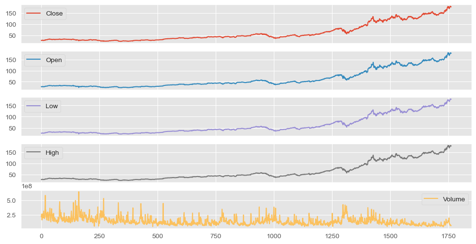

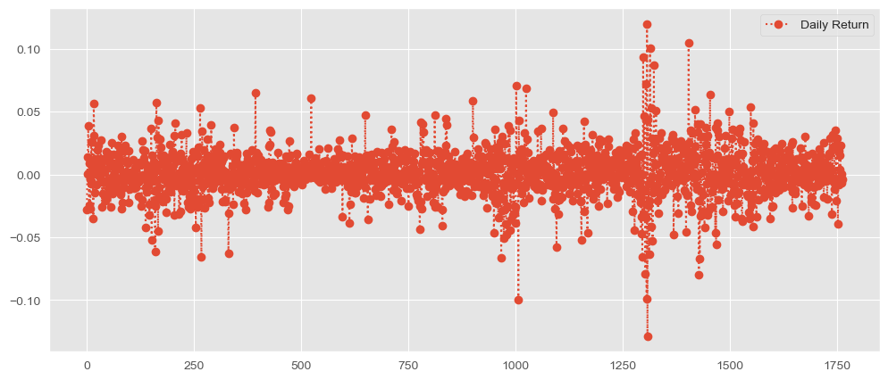

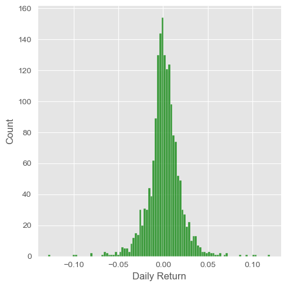

```python
data=dataset_train
data.plot(legend=True,subplots=True, figsize = (12, 6))
plt.show()
#data['Close'].plot(legend=True, figsize = (12, 6))
#plt.show()
#data['Volume'].plot(legend=True,figsize=(12,7))
#plt.show()

data.shape
data.size
data.describe(include='all').T
data.dtypes
data.nunique()
ma_day = [10,50,100]

for ma in ma_day:
    column_name = "MA for %s days" %(str(ma))
    data[column_name]=pd.DataFrame.rolling(data['Close'],ma).mean()

data['Daily Return'] = data['Close'].pct_change()
# plot the daily return percentage
data['Daily Return'].plot(figsize=(12,5),legend=True,linestyle=':',marker='o')
plt.show()

sns.displot(data['Daily Return'].dropna(),bins=100,color='green')
plt.show()
```

[figure not shown]

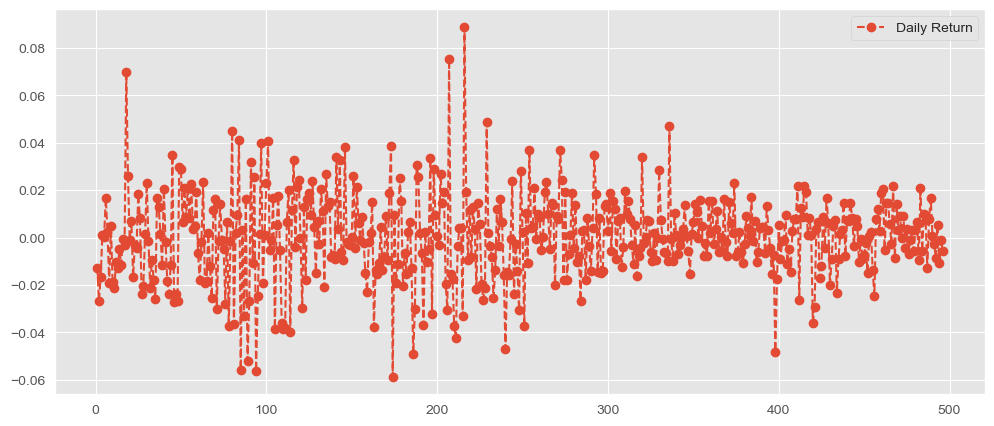

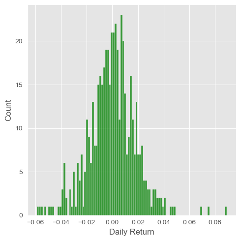

```python
# 首先，代码假定已经有一个名为 'dataset_val' 的Pandas DataFrame，它包含了金融数据
data = dataset_val
# 绘制DataFrame中所有列的线图，每个子图显示一列
data.plot(legend=True, subplots=True, figsize = (12, 6))
plt.show()
# 这里是一些被注释掉的代码，如果取消注释，它们将分别绘制'Close'和'Volume'列的图表
#data['Close'].plot(legend=True, figsize = (12, 6))
#plt.show()
#data['Volume'].plot(legend=True, figsize=(12, 6))
#plt.show()
# 显示DataFrame的形状（行数和列数）
data.shape
# 显示DataFrame中的元素总数
data.size
# 生成描述性统计数据，包括所有数值类型的列
data.describe(include='all').T
# 显示DataFrame中每列的数据类型
data.dtypes
# 显示DataFrame中每列不同值的数量
data.nunique()
# 定义一个列表，表示移动平均线的窗口大小
ma_day = [10, 50, 100]
# 对于列表中的每个窗口大小，计算'Close'列的移动平均，并创建一个新列
for ma in ma_day:
    column_name = f"MA for {ma} days"  # 格式化字符串，创建列名
    # 计算移动平均并将结果存储在新列中
    data[column_name] = pd.DataFrame.rolling(data['Close'], ma).mean()
# 计算DataFrame中'Close'列的日收益率，并将结果存储在新列'Daily Return'中
data['Daily Return'] = data['Close'].pct_change()
# 绘制'Daily Return'列的百分比变化图
data['Daily Return'].plot(figsize=(12, 5), legend=True, linestyle='--', marker='o')
plt.show()
# 使用seaborn库绘制'Daily Return'列的直方图，删除任何空值，设置100个箱子，颜色为绿色
sns.displot(data['Daily Return'].dropna(), bins=100, color='green')
plt.show()
```

## 3.2 Extend quant factors

*Factors extended in here:*

```python
#feature extend
#Alpha002: the balance of long and short power
#Calculate: [(CLOSE-LOW)-(HIGH-CLOSE)]/(HIGH-LOW)
dataset_train['alpha002'] = ((dataset_train['Close']-dataset_train['Low'])-(dataset_train['High']-dataset_train['Close']))/(dataset_train['High']-dataset_train['Low'])
dataset_val['alpha002'] = ((dataset_val['Close']-dataset_val['Low'])-(dataset_val['High']-dataset_val['Close']))/(dataset_val['High']-dataset_val['Low'])
```

```python
#Alpha003: unusual transaction
#Calculate: VOLUME/MEAN(VOLUME,(delay,VOLUME,1))
dataset_train['alpha003'] = dataset_train['Volume']
dataset_val['alpha003'] = dataset_val['Volume']

for i in range(1, (len(dataset_train['Close']-1))):
    dataset_train.loc[i, 'alpha003']  = 2*dataset_train.loc[i, 'Volume']/(dataset_train.loc[i, 'Volume']+dataset_train.loc[i-1, 'Volume'])+1
dataset_train.loc[0, 'alpha003'] = dataset_train.loc[1, 'alpha003']

for i in range(1, (len(dataset_val['Close']-1))):
   dataset_val.loc[i, 'alpha003']  = 2*dataset_val.loc[i, 'Volume']/(dataset_val.loc[i, 'Volume']+dataset_val.loc[i-1, 'Volume'])+1
dataset_val.loc[0, 'alpha003'] = dataset_val.loc[1, 'alpha003']
```

```python
#Alpha004: unusual open price detection
#Calculate: OPEN/(delay,CLOSE,1)+1
dataset_train['alpha004'] = dataset_train['Close']
dataset_val['alpha004'] = dataset_val['Close']

for i in range(1, (len(dataset_train['Close']-1))):
    dataset_train.loc[i, 'alpha004']  = dataset_train.loc[i, 'Open']/dataset_train.loc[i-1, 'Close']+1
dataset_train.loc[0, 'alpha004'] = dataset_train.loc[1, 'alpha004']

for i in range(1, (len(dataset_val['Close']-1))):
   dataset_val.loc[i, 'alpha004']  = dataset_val.loc[i, 'Open']/dataset_val.loc[i-1, 'Close']+1
dataset_val.loc[0, 'alpha004'] = dataset_val.loc[1, 'alpha004']
```

```python
#Alpha005: unusual price volitary
#Calculate: (HIGH-LOW)/(delay,CLOSE,1)+1
dataset_train['alpha005'] = dataset_train['Close']
dataset_val['alpha005'] = dataset_val['Close']

for i in range(1, (len(dataset_train['Close']-1))):
    dataset_train.loc[i, 'alpha005']  = (dataset_train.loc[i, 'High']-dataset_train.loc[i, 'Low'])/dataset_train.loc[i-1, 'Close']+1
dataset_train.loc[0, 'alpha005'] = dataset_train.loc[1, 'alpha005']

for i in range(1, (len(dataset_val['Close']-1))):
   dataset_val.loc[i, 'alpha005']  = (dataset_val.loc[i, 'High']-dataset_val.loc[i, 'Low'])/dataset_val.loc[i-1, 'Close']+1
dataset_val.loc[0, 'alpha005'] = dataset_val.loc[1, 'alpha005']
```

```python
dataset_train = dataset_train.drop(columns='Low')
dataset_train = dataset_train.drop(columns='High')
dataset_train = dataset_train.drop(columns='Open')
dataset_val = dataset_val.drop(columns='Low')
dataset_val = dataset_val.drop(columns='High')
dataset_val = dataset_val.drop(columns='Open')
```

```python
dataset_train.tail()
```

|  | Close | Volume | MA for 10 days | MA for 50 days | MA for 100 days | Daily Return | alpha002 | alpha003 | alpha004 | alpha005 |
| --- | --- | --- | --- | --- | --- | --- | --- | --- | --- | --- |
| 1758 | 180.330002 | 74919600 | 174.776001 | 159.597001 | 153.3444 | 0.022975 | 0.946271 | 2.045807 | 2.004595 | 1.019004 |
| 1759 | 179.289993 | 79144300 | 175.131000 | 160.286001 | 153.6667 | -0.005767 | -0.457147 | 2.027422 | 1.999057 | 1.015527 |
| 1760 | 179.380005 | 62348900 | 175.636000 | 160.942601 | 153.9991 | 0.000502 | -0.004014 | 1.881299 | 2.000223 | 1.013888 |
| 1761 | 178.199997 | 59773000 | 175.525999 | 161.531401 | 154.3202 | -0.006578 | -0.911290 | 1.978907 | 2.000502 | 1.013825 |
| 1762 | 177.570007 | 64062300 | 176.057001 | 162.097601 | 154.6399 | -0.003535 | -0.685266 | 2.034637 | 1.999383 | 1.011055 |

```python
# dataset_train = dataset_train.drop(columns='MA for 10 days')
# dataset_train = dataset_train.drop(columns='MA for 50 days')
# dataset_train = dataset_train.drop(columns='MA for 100 days')
# dataset_train = dataset_train.drop(columns='Daily Return')
# dataset_val = dataset_val.drop(columns='MA for 10 days')
# dataset_val = dataset_val.drop(columns='MA for 50 days')
# dataset_val = dataset_val.drop(columns='MA for 100 days')
# dataset_val = dataset_train.drop(columns='Daily Return')
```

```python
dataset_train.tail()
```

[output not shown]

```python
dataset_val.tail()
```

|  | Close | Volume | alpha002 | alpha003 | alpha004 | alpha005 |
| --- | --- | --- | --- | --- | --- | --- |
| 492 | 195.889999 | 55751900 | 0.339282 | 1.605971 | 1.992509 | 1.011338 |
| 493 | 196.940002 | 40714100 | 0.981142 | 1.844113 | 2.001378 | 1.005411 |
| 494 | 194.830002 | 52242800 | -1.000000 | 2.124022 | 1.999797 | 1.014471 |
| 495 | 194.679993 | 46482500 | -0.340787 | 1.941653 | 2.006519 | 1.018375 |
| 496 | 193.600006 | 37122800 | -0.483603 | 1.888049 | 2.002568 | 1.012533 |

```python
dataset_train.info()
```

```
<class 'pandas.core.frame.DataFrame'>
RangeIndex: 1763 entries, 0 to 1762
Data columns (total 6 columns):
 #   Column    Non-Null Count  Dtype
---  ------    --------------  -----
 0   Close     1763 non-null   float64
 1   Volume    1763 non-null   int64
 2   alpha002  1763 non-null   float64
 3   alpha003  1763 non-null   float64
 4   alpha004  1763 non-null   float64
 5   alpha005  1763 non-null   float64
dtypes: float64(5), int64(1)
memory usage: 82.8 KB
```

```python
dataset_val.info()
```

```
<class 'pandas.core.frame.DataFrame'>
RangeIndex: 497 entries, 0 to 496
Data columns (total 6 columns):
 #   Column    Non-Null Count  Dtype
---  ------    --------------  -----
 0   Close     497 non-null    float64
 1   Volume    497 non-null    int64
 2   alpha002  497 non-null    float64
 3   alpha003  497 non-null    float64
 4   alpha004  497 non-null    float64
 5   alpha005  497 non-null    float64
dtypes: float64(5), int64(1)
memory usage: 23.4 KB
```

## 3.3 Normalization

```python
# 获取训练集和验证集的行数
num_train = dataset_train.shape[0]
num_val = dataset_val.shape[0]
# 从DataFrame中提取值作为数组
mat_train = dataset_train.values
mat_val = dataset_val.values
# 初始化一个列表，用于存储合并后的数据
mat_total = []
# 遍历训练集数据并添加到合并后的列表中
for index in range(num_train):
    mat_total.append(mat_train[index])
# 遍历验证集数据并添加到合并后的列表中
for index in range(num_val):
    mat_total.append(mat_val[index])
```

```python
# 导入预处理模块的MinMaxScaler
from sklearn.preprocessing import MinMaxScaler

# 创建MinMaxScaler的实例
min_max_scaler = MinMaxScaler()
#X_std = (X - X.min(axis=0)) / (X.max(axis=0) - X.min(axis=0))
# 对合并后的数据应用归一化处理
minmax_total = min_max_scaler.fit_transform(mat_total)

# 将归一化后的数据转换为DataFrame，列名与训练集相同
total = pd.DataFrame(minmax_total, columns=dataset_train.columns)
```

```python
# 将归一化后的数据分割回训练集和验证集
train = total.head(num_train)
val = total.tail(num_val)
```

## 3.4 preprocess input

```python
window = 2
#lenth of sliding window
```

```python
# Training data preparation
input_train = train # Assume 'train' is a pre-defined DataFrame
seq_len = window
num_feature_train = len(input_train.columns) # Number of features in the dataset
mat_train = input_train.values # Convert DataFrame to numpy array
sequence_length = seq_len + 1 # Sequence length is window size + 1 for the target
sli_train = [] # List to hold the sliding window sequences

# Create sliding windows of sequences for the training data
for index in range(len(mat_train) - sequence_length):
    sli_train.append(mat_train[index: index + sequence_length])
sli_train = np.array(sli_train) # Convert list to numpy array
```

```python
# Split the sequences into inputs (x_train) and targets (y_train)
x_train = sli_train[:, :-1] # All rows, all but the last column
y_train = sli_train[:, -1][:, 0] # All rows, just the last column (target feature)
# Reshape for LSTM input
X_train = np.reshape(x_train, (x_train.shape[0], x_train.shape[1], num_feature_train))
```

```python
# Validation data preparation (similar to training data preparation)
input_val = val # Assume 'val' is a pre-defined DataFrame
num_feature_train = len(input_val.columns)  # Number of features in the dataset (should be the same as training)
mat_val = input_val.values # Convert DataFrame to numpy array
sli_val = [] # List to hold the sliding window sequences


# Create sliding windows of sequences for the validation data
for index in range(len(mat_val) - sequence_length):
    sli_val.append(mat_val[index: index + sequence_length])
sli_val = np.array(sli_val) # Convert list to numpy array
```

```python
# Split the sequences into inputs (x_test) and targets (y_test)
x_test = sli_val[:, :-1] # All rows, all but the last column
y_test = sli_val[:, -1][:, 0] # All rows, just the last column (target feature)
X_test = np.reshape(x_test, (x_test.shape[0], x_test.shape[1], num_feature_train)) # Reshape for LSTM input
```

```python
# Print shapes of the prepared datasets for confirmation
print(X_train.shape, y_train.shape, X_test.shape, y_test.shape)
```

```
(1760, 2, 6) (1760,) (494, 2, 6) (494,)
```

```python
# LSTM model parameters
input_size = len(dataset_train.iloc[1, :]) # Number of features
lstm_units = 128  # the number of hidden neural network
dropout = 0.01  # Dropout rate for regularization
epoch = 20   # Number of epochs to train
```

# 4. Model Construction

- We design a CNN-LSTM model based on the Attention mechanism, which can effectively capture local and global dependencies in sequential data.
- Attention can improve the effect of important time steps in LSTM, thereby further reducing the model prediction error. Attention essentially involves calculating the weighted average of the output vectors of the last layer of LSTM. The output vectors of the hidden layers of LSTM are used as inputs to the attention layer, which is trained through a fully connected layer. The weight size represents the importance of the hidden state at each time step for the prediction result.
- After repeated testing, we adopted ELU as the activation function in the convolutional layer and LSTM layer, and tanh as the activation function in the final fully connected layer.

```python
# For creating model and training
import tensorflow as tf
from tensorflow.keras.layers import Conv1D, LSTM, Dense, Dropout, Bidirectional, TimeDistributed
from tensorflow.keras.layers import MaxPooling1D, Flatten
from tensorflow.keras.regularizers import L1, L2
from tensorflow.keras.metrics import Accuracy
from tensorflow.keras.metrics import RootMeanSquaredError


inputs = Input(shape=(window, input_size))
model = Conv1D(filters=lstm_units, kernel_size=1, activation='elu')(inputs)
model = MaxPooling1D(pool_size=window)(model)
model = Dropout(dropout)(model)


model = Bidirectional(LSTM(lstm_units, activation='elu'), name='bilstm')(model)

attention = Dense(lstm_units * 2, activation='elu', name='attention_vec')(model)
model = Multiply()([model, attention])
outputs = Dense(1, activation='tanh')(model)
model = Model(inputs=inputs, outputs=outputs)

model.compile(loss='mse', optimizer='adam', metrics=['accuracy'])
#loss='mse'：mean_squared_error
model.summary()
```

```
Model: "model_1"
__________________________________________________________________________________________________
 Layer (type)                Output Shape                 Param #   Connected to
==================================================================================================
 input_2 (InputLayer)        [(None, 2, 6)]               0         []

 conv1d_1 (Conv1D)           (None, 2, 128)               896       ['input_2[0][0]']

 max_pooling1d_1 (MaxPoolin  (None, 1, 128)               0         ['conv1d_1[0][0]']
 g1D)

 dropout_1 (Dropout)         (None, 1, 128)               0         ['max_pooling1d_1[0][0]']

 bilstm (Bidirectional)      (None, 256)                  263168    ['dropout_1[0][0]']

 attention_vec (Dense)       (None, 256)                  65792     ['bilstm[0][0]']

 multiply_1 (Multiply)       (None, 256)                  0         ['bilstm[0][0]',
                                                                     'attention_vec[0][0]']

 dense_1 (Dense)             (None, 1)                    257       ['multiply_1[0][0]']

==================================================================================================
Total params: 330113 (1.26 MB)
Trainable params: 330113 (1.26 MB)
Non-trainable params: 0 (0.00 Byte)
__________________________________________________________________________________________________
```

# Train

```python
history = model.fit(X_train, y_train, epochs=epoch, batch_size=250, shuffle=False,
                    validation_data=(X_test, y_test))
```

```python
model.save('final_model-1.h5')  # 使用HDF5格式保存模型
```

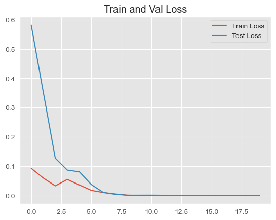

```python
loss = history.history['loss']
val_loss = history.history['val_loss']
epochs_range = range(epoch)
plt.plot(epochs_range, loss, label='Train Loss')
plt.plot(epochs_range, val_loss, label='Test Loss')
plt.legend(loc='upper right')
plt.title('Train and Val Loss')
plt.show()
```

# 6.Visualization

```python
import copy
y_train_predict = model.predict(X_train)
y_train_predict = y_train_predict[:, 0]
place_dataset_train = copy.deepcopy(train[3:])
place_dataset_train['Close'] = y_train_predict.reshape(-1, 1)
oritrain_predict = min_max_scaler.inverse_transform(place_dataset_train)
ytrain_pre_ori = oritrain_predict[:,0]
ytrain_ori = dataset_train['Close']
```

[output not shown]

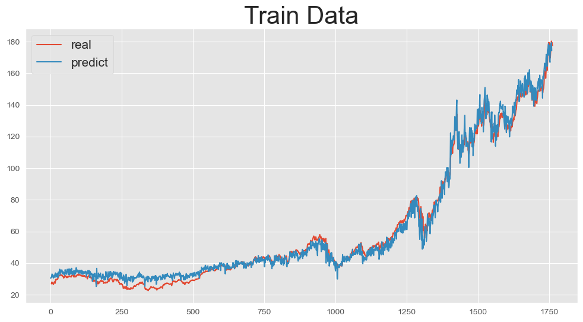

```python
draw = pd.concat([pd.DataFrame(ytrain_ori[3:]), pd.DataFrame(ytrain_pre_ori)], axis=1)
# print(y_train,y_train_predict,draw)
print(ytrain_ori[3:].shape,ytrain_pre_ori.shape,draw.shape)
# draw.iloc[200:500, 0].plot(figsize=(12, 6))
# draw.iloc[200:500, 1].plot(figsize=(12, 6))
draw.iloc[:, 0].plot(figsize=(12, 6))
draw.iloc[:, 1].plot(figsize=(12, 6))
plt.legend(('real', 'predict'), fontsize='15')
plt.title("Train Data", fontsize='30')
```

```
(1760,) (1760,) (1763, 2)
```

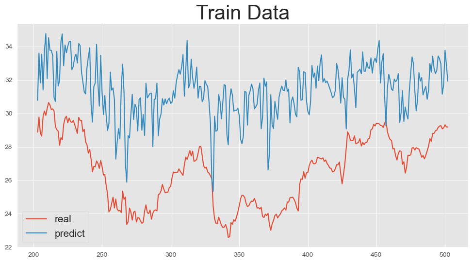

```python
draw = pd.concat([pd.DataFrame(ytrain_ori[3:]), pd.DataFrame(ytrain_pre_ori)], axis=1)
# print(y_train,y_train_predict,draw)
print(ytrain_ori[3:].shape,ytrain_pre_ori.shape,draw.shape)
draw.iloc[200:500, 0].plot(figsize=(12, 6))
draw.iloc[200:500, 1].plot(figsize=(12, 6))
# draw.iloc[:, 0].plot(figsize=(12, 6))
# draw.iloc[:, 1].plot(figsize=(12, 6))
plt.legend(('real', 'predict'), fontsize='15')
plt.title("Train Data", fontsize='30')
```

```python
y_test_predict = model.predict(X_test)
y_test_predict = y_test_predict[:, 0]
place_dataset_val = copy.deepcopy(val[3:])
place_dataset_val['Close'] = y_test_predict.reshape(-1, 1)
orival_predict = min_max_scaler.inverse_transform(place_dataset_val)
yval_pre_ori = orival_predict[:,0]
yval_ori = dataset_val['Close']
```

[output not shown]

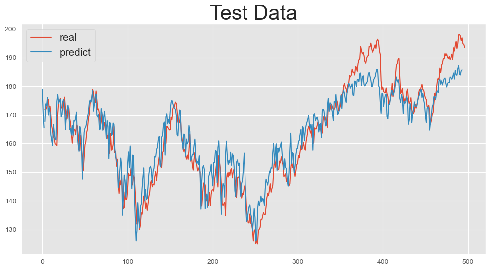

```python
draw = pd.concat([pd.DataFrame(yval_ori[3:]), pd.DataFrame(yval_pre_ori)], axis=1)
# print(y_train,y_train_predict,draw)
print(yval_ori[3:].shape,yval_pre_ori.shape,draw.shape)
# draw.iloc[200:500, 0].plot(figsize=(12, 6))
# draw.iloc[200:500, 1].plot(figsize=(12, 6))
draw.iloc[:, 0].plot(figsize=(12, 6))
draw.iloc[:, 1].plot(figsize=(12, 6))
plt.legend(('real', 'predict'), fontsize='15')
plt.title("Test Data", fontsize='30')

#download the result of predicition
# draw.to_csv(r"Test-Result.csv",sep=',')
```

```
(494,) (494,) (497, 2)
```

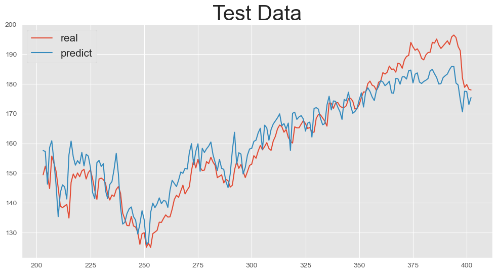

```python
draw = pd.concat([pd.DataFrame(yval_ori[3:]), pd.DataFrame(yval_pre_ori)], axis=1)
# print(y_train,y_train_predict,draw)
print(yval_ori[3:].shape,yval_pre_ori.shape,draw.shape)
draw.iloc[200:400, 0].plot(figsize=(12, 6))
draw.iloc[200:400, 1].plot(figsize=(12, 6))
plt.legend(('real', 'predict'), fontsize='15')
plt.title("Test Data", fontsize='30')

#download the result of predicition
# draw.to_csv(r"Test-Result.csv",sep=',')
```

# 7. Backtest

```python
def backtest(predictions, original_prices, threshold, initial_cash):
    """
    Backtest function to simulate trading based on the model's predictions.

    :param predictions: The predicted prices from the model.
    :param original_prices: The actual prices of the stock.
    :param threshold: The threshold for making a trade decision.
    :param initial_cash: The initial cash in the portfolio.
    :return: The final portfolio value and the total return.
    """
    cash = initial_cash
    shares = 0
    total_assets = initial_cash

    for i in range(1, len(predictions)):
        predicted_change = (predictions[i] - original_prices[i - 1]) / original_prices[i - 1]
        actual_change = (original_prices[i] - original_prices[i - 1]) / original_prices[i - 1]

        # Decision to buy
        if predicted_change > threshold and cash >= original_prices[i]:
            shares_bought = cash // original_prices[i]
            shares += shares_bought
            cash -= shares_bought * original_prices[i]

        # Decision to sell
        elif predicted_change < -threshold and shares > 0:
            cash += shares * original_prices[i]
            shares = 0

        # Update total assets value
        total_assets = cash + shares * original_prices[i]

    total_return = total_assets - initial_cash
    return total_assets, total_return
```

```python
#val dataset
initial_cash = 500000
threshold = 0.03
arryval_ori = yval_ori.to_numpy()
final_assets, total_return = backtest(yval_pre_ori, arryval_ori[3:], threshold=threshold, initial_cash=initial_cash)
return_rate = (total_return/initial_cash)*100
print("Final Assets:", final_assets, "Total Return:", total_return, "Return Rate:",return_rate)
```

```
Final Assets: 602330.6379241943 Total Return: 102330.63792419434 Return Rate: 20.466127584838866
```